# Human Activity Recognition

Radu Grosu

26 April 2016

# Introduction

Using devices such as Jawbone Up, Nike FuelBand, and Fitbit it is now possible to collect a large amount of data about personal activity relatively inexpensively. These type of devices are part of the quantified self movement - a group of enthusiasts who take measurements about themselves regularly to improve their health, to find patterns in their behavior, or because they are tech geeks. One thing that people regularly do is quantify how much of a particular activity they do, but they rarely quantify how well they do it. In this project, we use data from accelerometers on the belt, forearm, arm, and dumbbell. (Velloso et al. 2013).

Six young healthy participants were asked to perform barbell lifts correctly and incorrectly in 4 different ways. Given data from accelerometers, the goal is to predict the class of action which is one of the following:

- exactly according to the specification (A)
- throwing elbows to the front (B)
- lifting the dumbbell only halfway (C)
- lowering the dumbbell only halfway (D)
- throwing the hips to the front (E).

Class A corresponds to the specified execution of the exercise, while the other 4 classes correspond to common mistakes.

More information is available at [Groupware](http://groupware.les.inf.puc-rio.br/har) (see the section on the Weight Lifting Exercise Dataset).

# Getting and cleaning the data

```r
# loading the necessary packages
library(caret)
library(dplyr)
```

After downloading the csv files for the [training](https://d396qusza40orc.cloudfront.net/predmachlearn/pml-training.csv) and [testing](https://d396qusza40orc.cloudfront.net/predmachlearn/pml-testing.csv) set, we load the datasets into R.

```r
na_strings = c("NA", "", "#DIV/0!")
Tr = read.csv('data/pml-training.csv', na.strings=na_strings)
Te = read.csv('data/pml-testing.csv', na.strings=na_strings)
```

The training dataset consists of 19622 observations over 159 features. Only a small subset of the features turns out to be useful in predicting the `classe` outcome variable.

We drop the index, the name of the user, and various timestamps which cannot predict the outcome variable (or which could not possibly generalize).

```r
Tr = subset(Tr, select=-grep('X|time|user', names(Tr)))
Te = subset(Te, select=-grep('X|time|user', names(Te)))
```

The 96 derived features mentioned in (Velloso et al. 2013) (mean, variance, standard deviation, max, min, amplitude, kurtosis and skewness for the Euler angles of each of the four sensors) are present as columns in the dataset but contain only missing values, hence we drop these variables as well.

```r
NA_percent = apply(Tr, 2, function(x) mean(is.na(x)))
Tr[, NA_percent > .95] = list(NULL)
Te[, NA_percent > .95] = list(NULL)
```

The last variables to remove are those with zero and near-zero variance. These can be identified by the *frequency ratio* (the frequency of the most prevalent value over the second most frequent value) and the *percent of unique values* (the number of unique values divided by the total number of samples).

```r
nzvars = nearZeroVar(Tr, saveMetrics=TRUE, names=TRUE)
nzvars %>% head
```

```
##                  freqRatio percentUnique zeroVar   nzv
## new_window       47.330049    0.01019264   FALSE  TRUE
## num_window        1.000000    4.37264295   FALSE FALSE
## roll_belt         1.101904    6.77810621   FALSE FALSE
## pitch_belt        1.036082    9.37722964   FALSE FALSE
## yaw_belt          1.058480    9.97349913   FALSE FALSE
## total_accel_belt  1.063160    0.14779329   FALSE FALSE
```

```r
Tr[nzvars$nzv] = NULL
Te[nzvars$nzv] = NULL
```

This leaves the following 53 predictors for model building.

```r
Tr %>% names %>% subset(.!= "classe")
```

```
##  [1] "num_window"           "roll_belt"            "pitch_belt"
##  [4] "yaw_belt"             "total_accel_belt"     "gyros_belt_x"
##  [7] "gyros_belt_y"         "gyros_belt_z"         "accel_belt_x"
## [10] "accel_belt_y"         "accel_belt_z"         "magnet_belt_x"
## [13] "magnet_belt_y"        "magnet_belt_z"        "roll_arm"
## [16] "pitch_arm"            "yaw_arm"              "total_accel_arm"
## [19] "gyros_arm_x"          "gyros_arm_y"          "gyros_arm_z"
## [22] "accel_arm_x"          "accel_arm_y"          "accel_arm_z"
## [25] "magnet_arm_x"         "magnet_arm_y"         "magnet_arm_z"
## [28] "roll_dumbbell"        "pitch_dumbbell"       "yaw_dumbbell"
## [31] "total_accel_dumbbell" "gyros_dumbbell_x"     "gyros_dumbbell_y"
## [34] "gyros_dumbbell_z"     "accel_dumbbell_x"     "accel_dumbbell_y"
## [37] "accel_dumbbell_z"     "magnet_dumbbell_x"    "magnet_dumbbell_y"
## [40] "magnet_dumbbell_z"    "roll_forearm"         "pitch_forearm"
## [43] "yaw_forearm"          "total_accel_forearm"  "gyros_forearm_x"
## [46] "gyros_forearm_y"      "gyros_forearm_z"      "accel_forearm_x"
## [49] "accel_forearm_y"      "accel_forearm_z"      "magnet_forearm_x"
## [52] "magnet_forearm_y"     "magnet_forearm_z"
```

# Partitioning the data

We split the training dataset using stratified sampling on the outcome variable in two parts: a larger one used for training the model and a hold-out part used for assessing model performance. Keeping a reasonable large hold out set is justified by the large amount of data at our disposal allowing sufficient power and precision in the assessment of accuracy without introducing substantial bias into the model.

```r
set.seed(1)
inTrain <- createDataPartition(Tr$classe, p=0.7, list=FALSE)
tr <- Tr[inTrain, ]
te <- Tr[-inTrain, ]
```

# The models

We use the following two high-performance machine learning algorithms suitable for the classification setting: [random forest](https://en.wikipedia.org/wiki/Random_forest) and [boosted logistic regression](https://en.wikipedia.org/wiki/LogitBoost).

Neither of these methods are sensitive to skewness and difference of scale in the variables so no further pre-processing is necessary.

Train the *Boosted Logistic regression* model:

```r
# LB = train(classe ~., method='LogitBoost', data=tr)
# save(LB, file='LB.Rdata')
load("LB.RData")
print(LB)
```

```
## Boosted Logistic Regression
##
## 13737 samples
##    53 predictors
##     5 classes: 'A', 'B', 'C', 'D', 'E'
##
## No pre-processing
## Resampling: Bootstrapped (25 reps)
## Summary of sample sizes: 13737, 13737, 13737, 13737, 13737, 13737, ...
## Resampling results across tuning parameters:
##
##   nIter  Accuracy   Kappa
##   11     0.8389411  0.7920526
##   21     0.9004023  0.8728640
##   31     0.9254236  0.9050272
##
## Accuracy was used to select the optimal model using  the largest value.
## The final value used for the model was nIter = 31.
```

```r
confusionMatrix(te$classe, predict(LB, newdata=te))
```

```
## Confusion Matrix and Statistics
##
##           Reference
## Prediction    A    B    C    D    E
##          A 1555   19    4    4   11
##          B   59  857   36    8   10
##          C    2   34  821   27    1
##          D    3   13   25  812    8
##          E    3   12    8   16  962
##
## Overall Statistics
##
##                Accuracy : 0.9429
##                  95% CI : (0.9364, 0.949)
##     No Information Rate : 0.3055
##     P-Value [Acc > NIR] : < 2.2e-16
##
##                   Kappa : 0.9274
##  Mcnemar's Test P-Value : 0.0001021
##
## Statistics by Class:
##
##                      Class: A Class: B Class: C Class: D Class: E
## Sensitivity            0.9587   0.9166   0.9183   0.9366   0.9698
## Specificity            0.9897   0.9742   0.9855   0.9890   0.9910
## Pos Pred Value         0.9761   0.8835   0.9277   0.9431   0.9610
## Neg Pred Value         0.9820   0.9820   0.9835   0.9876   0.9930
## Prevalence             0.3055   0.1761   0.1684   0.1633   0.1868
## Detection Rate         0.2928   0.1614   0.1546   0.1529   0.1812
## Detection Prevalence   0.3000   0.1827   0.1667   0.1621   0.1885
## Balanced Accuracy      0.9742   0.9454   0.9519   0.9628   0.9804
```

For the *random forest* model, using bootstrapped resampling and 10-fold cross-validation with 10 repeats leads to nearly indistinguishable models (the cross-validation resampling takes more than double the time to train though).

The random forest using the default bootstrapping resampling:

```r
# RF = train(classe ~ ., method="rf", data=tr)
# save(RF, file='RF.Rdata')
load(file='RF.RData')
print(RF)
```

```
## Random Forest
##
## 13737 samples
##    53 predictors
##     5 classes: 'A', 'B', 'C', 'D', 'E'
##
## No pre-processing
## Resampling: Bootstrapped (25 reps)
## Summary of sample sizes: 13737, 13737, 13737, 13737, 13737, 13737, ...
## Resampling results across tuning parameters:
##
##   mtry  Accuracy   Kappa
##    2    0.9914787  0.9892160
##   27    0.9950759  0.9937694
##   53    0.9900678  0.9874306
##
## Accuracy was used to select the optimal model using  the largest value.
## The final value used for the model was mtry = 27.
```

```r
confusionMatrix(te$classe, predict(RF, newdata=te))
```

```
## Confusion Matrix and Statistics
##
##           Reference
## Prediction    A    B    C    D    E
##          A 1674    0    0    0    0
##          B    1 1138    0    0    0
##          C    0    0 1026    0    0
##          D    0    0    0  964    0
##          E    0    0    0    0 1082
##
## Overall Statistics
##
##                Accuracy : 0.9998
##                  95% CI : (0.9991, 1)
##     No Information Rate : 0.2846
##     P-Value [Acc > NIR] : < 2.2e-16
##
##                   Kappa : 0.9998
##  Mcnemar's Test P-Value : NA
##
## Statistics by Class:
##
##                      Class: A Class: B Class: C Class: D Class: E
## Sensitivity            0.9994   1.0000   1.0000   1.0000   1.0000
## Specificity            1.0000   0.9998   1.0000   1.0000   1.0000
## Pos Pred Value         1.0000   0.9991   1.0000   1.0000   1.0000
## Neg Pred Value         0.9998   1.0000   1.0000   1.0000   1.0000
## Prevalence             0.2846   0.1934   0.1743   0.1638   0.1839
## Detection Rate         0.2845   0.1934   0.1743   0.1638   0.1839
## Detection Prevalence   0.2845   0.1935   0.1743   0.1638   0.1839
## Balanced Accuracy      0.9997   0.9999   1.0000   1.0000   1.0000
```

The random forest using 10-fold cross-validation with 10 repeats.

```r
# ctrl <- trainControl(method = "repeatedcv", number=10, repeats=10)
# RF2 = train(classe ~ ., method="rf", data=tr, trControl=ctrl)
# save(RF2, file='RF2.Rdata')
load(file='RF2.RData')
print(RF2)
```

```
## Random Forest
##
## 13737 samples
##    53 predictors
##     5 classes: 'A', 'B', 'C', 'D', 'E'
##
## No pre-processing
## Resampling: Cross-Validated (10 fold, repeated 10 times)
## Summary of sample sizes: 12363, 12364, 12363, 12364, 12362, 12362, ...
## Resampling results across tuning parameters:
##
##   mtry  Accuracy   Kappa
##    2    0.9941764  0.9926332
##   27    0.9973211  0.9966115
##   53    0.9948242  0.9934528
##
## Accuracy was used to select the optimal model using  the largest value.
## The final value used for the model was mtry = 27.
```

```r
confusionMatrix(te$classe, predict(RF2, newdata=te))
```

```
## Confusion Matrix and Statistics
##
##           Reference
## Prediction    A    B    C    D    E
##          A 1674    0    0    0    0
##          B    1 1138    0    0    0
##          C    0    0 1026    0    0
##          D    0    0    0  964    0
##          E    0    0    0    0 1082
##
## Overall Statistics
##
##                Accuracy : 0.9998
##                  95% CI : (0.9991, 1)
##     No Information Rate : 0.2846
##     P-Value [Acc > NIR] : < 2.2e-16
##
##                   Kappa : 0.9998
##  Mcnemar's Test P-Value : NA
##
## Statistics by Class:
##
##                      Class: A Class: B Class: C Class: D Class: E
## Sensitivity            0.9994   1.0000   1.0000   1.0000   1.0000
## Specificity            1.0000   0.9998   1.0000   1.0000   1.0000
## Pos Pred Value         1.0000   0.9991   1.0000   1.0000   1.0000
## Neg Pred Value         0.9998   1.0000   1.0000   1.0000   1.0000
## Prevalence             0.2846   0.1934   0.1743   0.1638   0.1839
## Detection Rate         0.2845   0.1934   0.1743   0.1638   0.1839
## Detection Prevalence   0.2845   0.1935   0.1743   0.1638   0.1839
## Balanced Accuracy      0.9997   0.9999   1.0000   1.0000   1.0000
```

```r
RF2$finalModel
```

```
##
## Call:
##  randomForest(x = x, y = y, mtry = param$mtry, verbose = ..1)
##                Type of random forest: classification
##                      Number of trees: 500
## No. of variables tried at each split: 27
##
##         OOB estimate of  error rate: 0.23%
## Confusion matrix:
##      A    B    C    D    E  class.error
## A 3905    0    0    0    1 0.0002560164
## B    6 2648    3    1    0 0.0037622272
## C    0    6 2390    0    0 0.0025041736
## D    0    0   10 2241    1 0.0048845471
## E    0    0    1    2 2522 0.0011881188
```

In fact, there is a single misclassified point in the entire test set:

```r
predictions = predict(RF2, newdata=te)
misclass = which(te$classe != predictions)
paste("Activity", te[misclass, "classe"], "misclassified as", predictions[misclass])
```

```
## [1] "Activity B misclassified as A"
```

# Model Comparison

Since the first two models (`LB` and `RF`) share a common set of resampled data sets we can compare them based on their resampling statistics.

```r
resamp <- resamples(list(Logistic = LB, RandForest=RF))
summary(resamp)
```

```
##
## Call:
## summary.resamples(object = resamp)
##
## Models: Logistic, RandForest
## Number of resamples: 25
##
## Accuracy
##              Min. 1st Qu. Median   Mean 3rd Qu.   Max. NA's
## Logistic   0.9107  0.9197 0.9241 0.9254  0.9308 0.9373    0
## RandForest 0.9925  0.9940 0.9953 0.9951  0.9962 0.9974    0
##
## Kappa
##              Min. 1st Qu. Median   Mean 3rd Qu.   Max. NA's
## Logistic   0.8860  0.8983 0.9032 0.9050  0.9118 0.9204    0
## RandForest 0.9905  0.9924 0.9940 0.9938  0.9952 0.9967    0
```

The performance distribution of the random forest model has both a higher mean and lower variance than that of the boosted logistic regression.

```r
model.diffs <- diff(resamp)
summary(model.diffs)
```

```
##
## Call:
## summary.diff.resamples(object = model.diffs)
##
## p-value adjustment: bonferroni
## Upper diagonal: estimates of the difference
## Lower diagonal: p-value for H0: difference = 0
##
## Accuracy
##            Logistic  RandForest
## Logistic             -0.06965
## RandForest < 2.2e-16
##
## Kappa
##            Logistic  RandForest
## Logistic             -0.08874
## RandForest < 2.2e-16
```

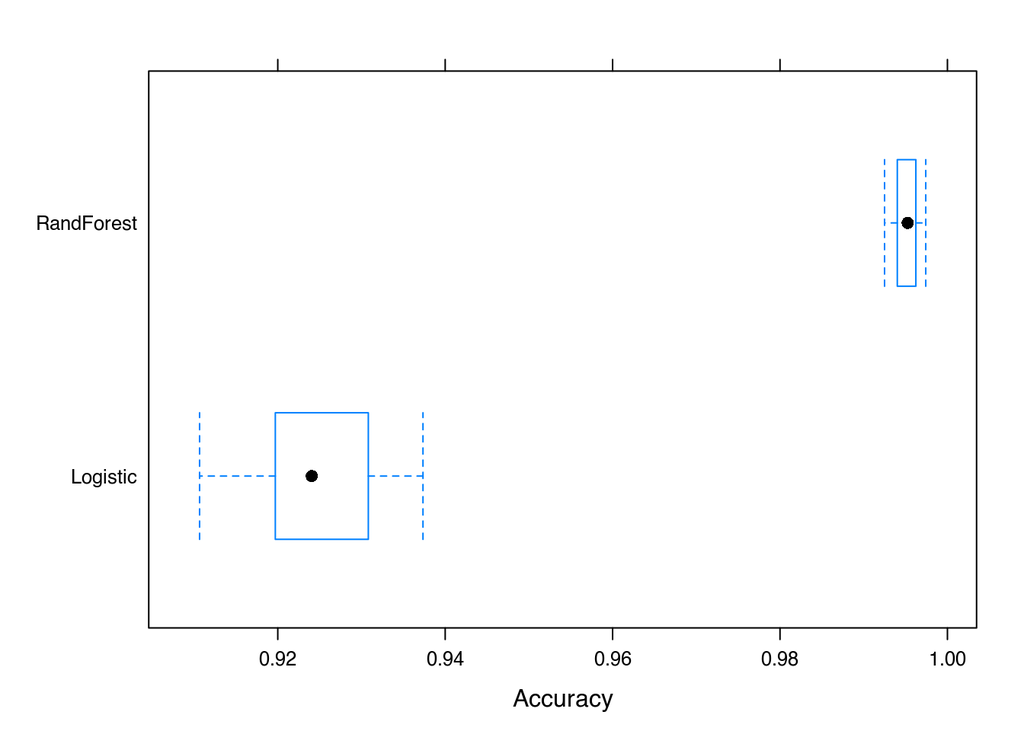

```r
bwplot(resamp, metric="Accuracy")
```

The variable importance for the random forest model:

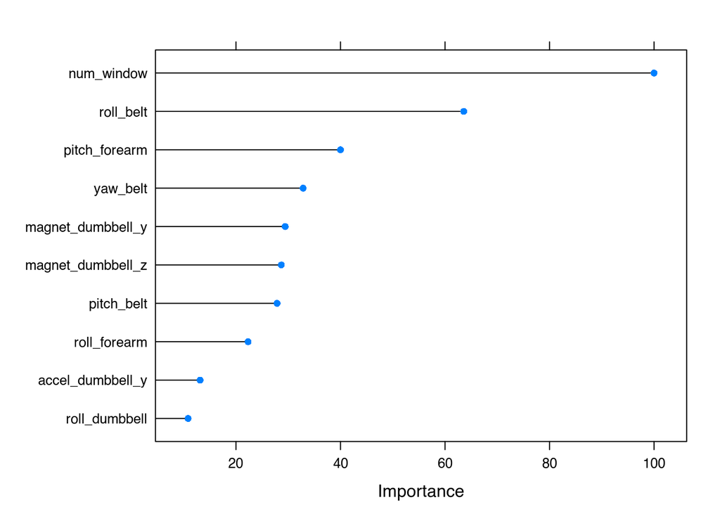

```r
plot(varImp(RF), top=10)
```

The `num_window` variable which separates measurements from different repetitions is not surprisingly crucial in successfully partitioning of the feature space.

# Predictions on the test set

```r
predict(RF, newdata=Te)
```

```
##  [1] B A B A A E D B A A B C B A E E A B B B
## Levels: A B C D E
```

# References

Velloso, Eduardo, Andreas Bulling, Hans Gellersen, Wallace Ugulino, and Hugo Fuks. 2013. “Qualitative Activity Recognition of Weight Lifting Exercises.” In *Proceedings of the 4th Augmented Human International Conference*, 116–23. AH ’13. New York, NY, USA: ACM. doi:10.1145/2459236.2459256.